# ADHD management

# ADHD Analysis

```r
figure_height <- 10
```

```r
# ADHD Analysis 2025-04-23
library(broom)
library(dplyr)
library(glue)
library(htmltools)
library(knitr)
library(kableExtra)
library(metafor)
#| label: init

# Debug: Print the path to the console during rendering
message("--- Debug: Attempting to load from path: ", params$data_path, " ---")
```

```
--- Debug: Attempting to load from path: C:/Users/SusanneH/Documents/adhd_management/adhd_params.RData ---
```

```r
if (exists("params") && !is.null(params$data_path) && params$data_path != "") {
  # Safe check to see if the file actually exists from Quarto's perspective
  if (file.exists(params$data_path)) {
    load(params$data_path)
  } else {
    stop("The file path was passed, but the file does not exist at: ", params$data_path)
  }
}


# Load using the absolute path passed from the main script
if (params$data_path != "") {
  load(params$data_path)
}
```

```r
# Remove empty intervention
d <- d %>% dplyr::filter(intervention != "")


# find the continuous variable intervention names
int_continuous_vars <-
  d %>%
  dplyr::select(ends_with("mean_int_cont")) %>%
  names() %>%
  gsub("_.+", "", .)

ctrl_continuous_vars <-
  d %>%
  dplyr::select(ends_with("mean_ctrl_cont")) %>%
  names() %>%
  gsub("_.+", "", .)



list_variable_types <-
  list(
    c(var = "functional", type = "continuous"),
    c(var = "functional", type = "categorical"),
    c(var = "cognitive", type = "continuous"),
    c(var = "cognitive", type = "categorical"),
    c(var = "symptom", type = "continuous"),
    c(var = "symptom", type = "categorical"),
    c(var = "substance_use", type = "continuous"),
    c(var = "substance_use", type = "categorical"),
    c(var = "relationship", type = "continuous"),
    c(var = "relationship", type = "categorical"),
    c(var = "BP", type = "continuous"),
    c(var = "BP", type = "categorical"),
    c(var = "sleep_disturbance", type = "continuous"),
    c(var = "sleep_disturbance", type = "categorical"),
    c(var = "AEs", type = "continuous"),
    c(var = "AEs", type = "categorical"),
    c(var = "mortality", type = "continuous"),
    c(var = "mortality", type = "categorical"),
    c(var = "behavior", type = "continuous"),
    c(var = "behavior", type = "categorical"),
    c(var = "appetite", type = "continuous"),
    c(var = "appetite", type = "categorical"),
    c(var = "mood", type = "continuous"),
    c(var = "mood", type = "categorical")
  )


int_continuous_vars <-
  ifelse(int_continuous_vars == "substance",
         "substance_use",
         int_continuous_vars
  )
int_continuous_vars <-
  ifelse(int_continuous_vars == "sleep",
         "sleep_disturbance",
         int_continuous_vars
  )

if (length(int_continuous_vars) != length(ctrl_continuous_vars)) {
  stop("Problem with continuous variables")
}



# find the categorical variable outcome names
int_categ_vars <-
  d %>%
  dplyr::select(ends_with("int_categ")) %>%
  names() %>%
  gsub("_.+", "", .) %>%
  unique()

ctrl_categ_vars <-
  d %>%
  dplyr::select(ends_with("ctrl_categ")) %>%
  names() %>%
  gsub("_.+", "", .) %>%
  unique()

int_categ_vars <-
  ifelse(int_categ_vars == "substance", "substance_use", int_categ_vars)
int_categ_vars <-
  ifelse(int_categ_vars == "sleep", "sleep_disturbance", int_categ_vars)

if (length(int_categ_vars) != length(ctrl_categ_vars)) {
  stop("Problem with continuous variables")
}

# need to rename substance to substance_use


# Check the direction for each outcome that we want for the effects and
# forest plots.
# Variable says what we want on the right hand side of the x-axis.
# e.g. blood pressure lower <-----> higher,
# cognitive higher <---------> lower
d <-  d %>%
  dplyr::mutate(
    # continuous directions
    AEs_positive_direction = "higher",
    appetite_positive_direction =  "higher",   ######### Check
    behavior_positive_direction = "lower",
    BP_positive_direction = "higher",
    cognitive_positive_direction = "lower",
    functional_positive_direction = "higher",
    mood_positive_direction = "higher",   ######### Check
    mortality_positive_direction = "lower",
    relationship_positive_direction = "higher",
    sleep_disturbance_positive_direction = "higher",
    substance_use_positive_direction = "lower",
    symptom_positive_direction = "higher",
    # categorical
    AEs_positive_direction_categ = "higher",
    appetite_positive_direction_categ = "lower",
    behavior_positive_direction_categ = "lower",
    BP_positive_direction_categ = "lower",
    cognitive_positive_direction_categ = "higher",
    functional_positive_direction_categ = "lower",
    mood_positive_direction_categ = "lower",     # check
    mortality_positive_direction_categ = "lower",
    relationship_positive_direction_categ = "lower",
    sleep_disturbance_positive_direction_categ = "higher",
    substance_use_positive_direction_categ = "higher",
    symptom_positive_direction_categ = "higher"
  )
```

Read the functions to do MA:

```r
source(glue::glue(git_raw_root, "/helper_functions/AmphMphMetaReg.R"))
source(glue::glue(git_raw_root, "/helper_functions/CatMA.R"))
source(glue::glue(git_raw_root, "/helper_functions/CombinedMetaregs.R"))
source(glue::glue(git_raw_root, "/helper_functions/contMA.R"))
source(glue::glue(git_raw_root, "/helper_functions/MPH_Dose_metareg.R"))
source(glue::glue(git_raw_root, "/helper_functions/StimMetaReg.R"))
```

```r
d <- d %>%
  dplyr::mutate(
    symptom_SD_ctrl_cont = ifelse(symptom_SD_ctrl_cont  < 0, NA, symptom_SD_ctrl_cont),
    symptom_SD_int_cont = ifelse(symptom_SD_int_cont  < 0, NA, symptom_SD_int_cont),
  )
```

# All interventions

```r
for (var_num in 1:length(list_variable_types)) {
  current_intervention <- ""
  outcome_name <- list_variable_types[[var_num]]["var"]
  outcome_type <- list_variable_types[[var_num]]["type"]

  cat(
    glue::glue("<h2> Intervention: All Interventions <br>
                <h3>Outcome: {outcome_name}:{outcome_type}</h3><p>")
  )

  if (outcome_type == "continuous") {
    res <- ContMA(
      data = d,
      label = "ID",
      outcome = outcome_name,
      comparator_vs_int = comparator_vs_int
    )
  }
  if (outcome_type == "categorical") {
    res <- CatMA(
      data = d,
      label = "ID",
      outcome = outcome_name,
      comparator_vs_int = comparator_vs_int
    )
  }
}
```

## Intervention: All Interventions

### Outcome: functional:continuous

| ID | measure | mean_ctrl_cont | SD_ctrl_cont | n_ctrl_cont | mean_int_cont | SD_int_cont | n_int_cont | yi | se | study.design |
| --- | --- | --- | --- | --- | --- | --- | --- | --- | --- | --- |
| Shim, 2022{#3242} NS-NRI-ATX | SDS (Sheehan Disability Scale) | 3.906 | 6.827 | 22 | 4.464 | 7.623 | 19 | -0.0759423 | 0.3132993 | RCT |

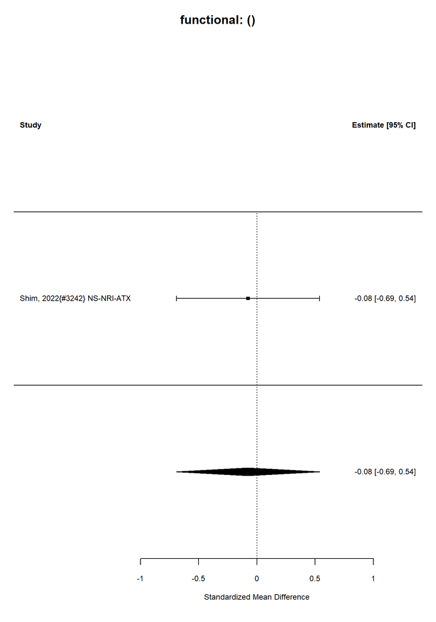

| estimate | conf.low | conf.high |
| --- | --- | --- |
| -0.08 | -0.69 | 0.54 |

Number of studies = 1

Intervention sample = 19

Control sample = 22

Total sample = 41.

I-squared = 0 %

Convert Effect Size to Real Units

Estimated effect in original units = -0.52.

## Intervention: All Interventions

### Outcome: functional:categorical

Analyzing 0 studies.

No data.

## Intervention: All Interventions

### Outcome: cognitive:continuous

No data #1.

## Intervention: All Interventions

### Outcome: cognitive:categorical

Analyzing 0 studies.

No data.

## Intervention: All Interventions

### Outcome: symptom:continuous

| ID | measure | mean_ctrl_cont | SD_ctrl_cont | n_ctrl_cont | mean_int_cont | SD_int_cont | n_int_cont | yi | se | study.design |
| --- | --- | --- | --- | --- | --- | --- | --- | --- | --- | --- |
| Kay, 2009{#2637} NS-NRI-ATX | ADHD-RS-IV (ADHD Rating Scale IV, Adult) | 18.400 | 7.200 | 15 | 27.800 | 6.900 | 14 | 1.2945790 | 0.4086449 | Crossover |
| Shim, 2022{#3242} NS-NRI-ATX | ASRS (Adult ADHD Self-Report Scale), change from baseline | 8.469 | 10.907 | 22 | 9.857 | 12.492 | 19 | -0.1166796 | 0.3134520 | RCT |
| Weisler, 2012{#1844} NS-NRI-ATX | ADHD-RS-IV (Attention-Deficit/Hyperactivity Disorder Rating Scale, Version IV) change from baseline | -15.700 | 13.390 | 68 | -15.300 | 14.520 | 73 | 0.0284439 | 0.1685449 | RCT |

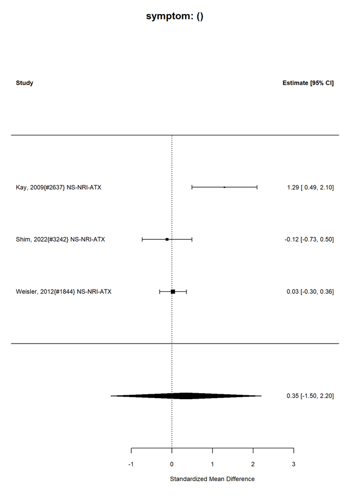

| estimate | conf.low | conf.high |
| --- | --- | --- |
| 0.35 | -1.5 | 2.2 |

Number of studies = 3

Intervention sample = 106

Control sample = 105

Total sample = 211.

I-squared = 84 %

Convert Effect Size to Real Units

Estimated effect in original units = 3.66.

##### Publication Bias Tests

###### Begg (non-parametric)

Rank Correlation Test for Funnel Plot Asymmetry Kendall’s tau = 1.0000, p = 0.3333

###### Egger (parametric)

Regression Test for Funnel Plot Asymmetry

Model: mixed-effects meta-regression model Predictor: standard error

Test for Funnel Plot Asymmetry: t = 1.0537, df = 1, p = 0.4834 Limit Estimate (as sei -> 0): b = -0.9240 (CI: -17.1864, 15.3384)

###### Trim and Fill

Estimate and Cis

|  | estimate | ci.lb | ci.ub |
| --- | --- | --- | --- |
| intrcpt | 0.35 | -1.5 | 2.2 |

### Meta-regression: stimulant vs non-stimulant

3 stimulant studies

0 nonstimulant studies

Not enough studies to compare stimulant and nonstimulant

### Meta-regression: AMPH vs MPH

### AMPH vs MPH meta-regression

1n AMPH studies

2 nMPH studies

Not enough studies to compare AMPH and MPH

## Meta-regression: Indirect comparison between combined vs(medication plus psychosocial) and medication

3 medication studies

0 combined studies

Not enough studies to compare medication and combined

## Meta-regression: Indirect comparison between combined vs(medication plus psychosocial) and psychosocial

0 psychosocial studies

0 combined studies

Not enough studies to compare psychosocial and combined

## Intervention: All Interventions

### Outcome: symptom:categorical

Analyzing 1 studies.

Analyzing 1 studies.

### Control Types

| control | n |
| --- | --- |
| Placebo | 1 |

| ID | measure | yi | se | study.design |
| --- | --- | --- | --- | --- |
| Kay, 2009{#2637} NS-NRI-ATX | ADHD-RS score improvement from baseline (≥ 30% decrease from baseline) | 0.62 | 0.33 | Crossover |

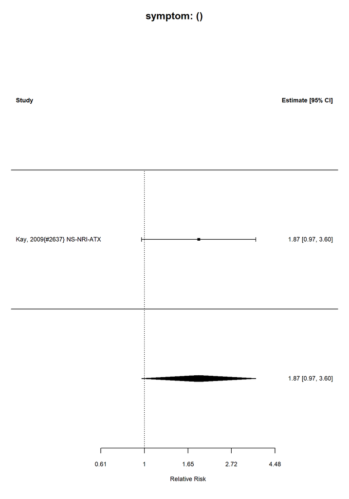

Number of studies = 1  
Intervention sample = 14  
Control sample = 14  
Total sample = 28

### Relative Risk Estimate

|  | estimate | se | zval | pval | ci.lb | ci.ub |
| --- | --- | --- | --- | --- | --- | --- |
| intrcpt | 1.858928 | 1.390968 | 6.488296 | 1.061837 | 0.9704455 | 3.59664 |

I-squared = 0 %

## Intervention: All Interventions

### Outcome: substance_use:continuous

No data #1.

## Intervention: All Interventions

### Outcome: substance_use:categorical

Analyzing 0 studies.

No data.

## Intervention: All Interventions

### Outcome: relationship:continuous

No data #1.

## Intervention: All Interventions

### Outcome: relationship:categorical

Analyzing 0 studies.

No data.

## Intervention: All Interventions

### Outcome: BP:continuous

| ID | measure | mean_ctrl_cont | SD_ctrl_cont | n_ctrl_cont | mean_int_cont | SD_int_cont | n_int_cont | yi | se | study.design |
| --- | --- | --- | --- | --- | --- | --- | --- | --- | --- | --- |
| Kay, 2009{#2637} NS-NRI-ATX | Systolic blood pressure | 120.5 | 7.2 | 15 | 118.1 | 7.0 | 14 | -0.3283321 | 0.3741041 | Crossover |
| Shim, 2022{#3242} NS-NRI-ATX | Systolic blood pressure | 124.4 | 14.4 | 22 | 121.6 | 8.9 | 19 | -0.2255362 | 0.3141758 | RCT |

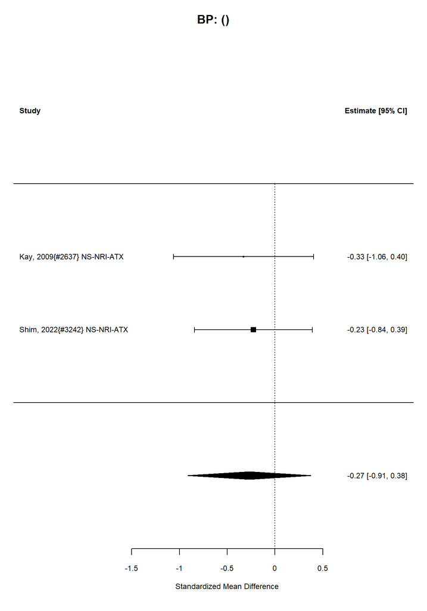

| estimate | conf.low | conf.high |
| --- | --- | --- |
| -0.27 | -0.91 | 0.38 |

Number of studies = 2

Intervention sample = 33

Control sample = 37

Total sample = 70.

I-squared = 0 %

Convert Effect Size to Real Units

Estimated effect in original units = -2.89.

## Intervention: All Interventions

### Outcome: BP:categorical

Analyzing 0 studies.

No data.

## Intervention: All Interventions

### Outcome: sleep_disturbance:continuous

No data #1.

## Intervention: All Interventions

### Outcome: sleep_disturbance:categorical

Analyzing 1 studies.

Analyzing 1 studies.

### Control Types

| control | n |
| --- | --- |
| Placebo | 1 |

| ID | measure | yi | se | study.design |
| --- | --- | --- | --- | --- |
| Weisler, 2012{#1844} NS-NRI-ATX | Number of participants reporting insomnia | -1.47 | 1.11 | RCT |

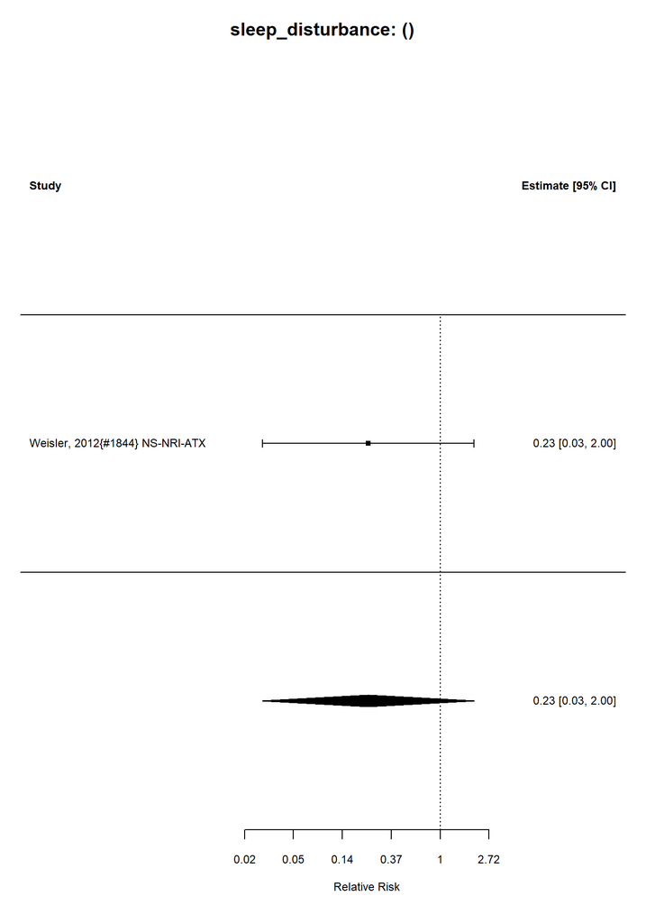

Number of studies = 1  
Intervention sample = 74  
Control sample = 73  
Total sample = 147

### Relative Risk Estimate

|  | estimate | se | zval | pval | ci.lb | ci.ub |
| --- | --- | --- | --- | --- | --- | --- |
| intrcpt | 0.2299255 | 3.034358 | 0.2644773 | 1.197217 | 0.0262523 | 2.013753 |

I-squared = 0 %

## Intervention: All Interventions

### Outcome: AEs:continuous

No data #1.

## Intervention: All Interventions

### Outcome: AEs:categorical

Analyzing 1 studies.

Analyzing 1 studies.

### Control Types

| control | n |
| --- | --- |
| Placebo | 1 |

| ID | measure | yi | se | study.design |
| --- | --- | --- | --- | --- |
| Weisler, 2012{#1844} NS-NRI-ATX | Number of participants reporting any adverse events | 0.02 | 0.08 | RCT |

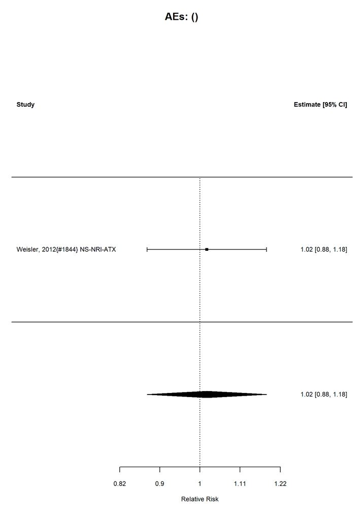

Number of studies = 1  
Intervention sample = 74  
Control sample = 73  
Total sample = 147

### Relative Risk Estimate

|  | estimate | se | zval | pval | ci.lb | ci.ub |
| --- | --- | --- | --- | --- | --- | --- |
| intrcpt | 1.020201 | 1.083287 | 1.2586 | 2.2705 | 0.8780954 | 1.185305 |

I-squared = 0 %

## Intervention: All Interventions

### Outcome: mortality:continuous

No data #1.

## Intervention: All Interventions

### Outcome: mortality:categorical

Analyzing 1 studies.

Analyzing 1 studies.

### Control Types

| control | n |
| --- | --- |
| Placebo | 1 |

| ID | measure | yi | se | study.design |
| --- | --- | --- | --- | --- |
| Weisler, 2012{#1844} NS-NRI-ATX | Number of deaths | 0.08 | 1.99 | RCT |

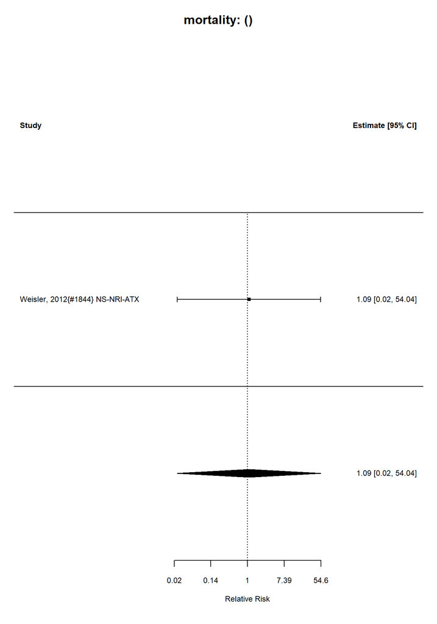

Number of studies = 1  
Intervention sample = 74  
Control sample = 73  
Total sample = 147

### Relative Risk Estimate

|  | estimate | se | zval | pval | ci.lb | ci.ub |
| --- | --- | --- | --- | --- | --- | --- |
| intrcpt | 1.083287 | 7.315534 | 1.040811 | 2.637945 | 0.0219278 | 54.05489 |

I-squared = 0 %

## Intervention: All Interventions

### Outcome: behavior:continuous

No data #1.

## Intervention: All Interventions

### Outcome: behavior:categorical

Analyzing 0 studies.

No data.

## Intervention: All Interventions

### Outcome: appetite:continuous

No data #1.

## Intervention: All Interventions

### Outcome: appetite:categorical

Analyzing 1 studies.

Analyzing 1 studies.

### Control Types

| control | n |
| --- | --- |
| Placebo | 1 |

| ID | measure | yi | se | study.design |
| --- | --- | --- | --- | --- |
| Weisler, 2012{#1844} NS-NRI-ATX | Decreased appetite adverse event | -0.8 | 0.42 | RCT |

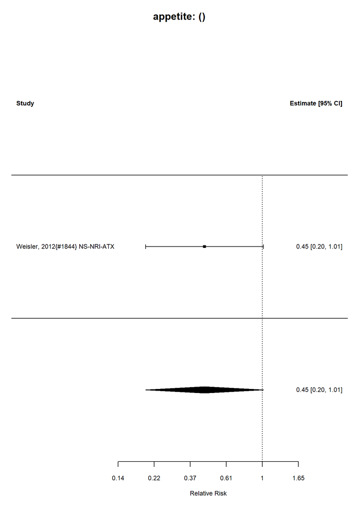

Number of studies = 1  
Intervention sample = 74  
Control sample = 73  
Total sample = 147

### Relative Risk Estimate

|  | estimate | se | zval | pval | ci.lb | ci.ub |
| --- | --- | --- | --- | --- | --- | --- |
| intrcpt | 0.449329 | 1.521962 | 0.1451482 | 1.051271 | 0.1978987 | 1.01005 |

I-squared = 0 %

## Intervention: All Interventions

### Outcome: mood:continuous

No data #1.

## Intervention: All Interventions

### Outcome: mood:categorical

Analyzing 1 studies.

Analyzing 1 studies.

### Control Types

| control | n |
| --- | --- |
| Placebo | 1 |

| ID | measure | yi | se | study.design |
| --- | --- | --- | --- | --- |
| Kay, 2009{#2637} NS-NRI-ATX | Irritability | 1.61 | 1.51 | Crossover |

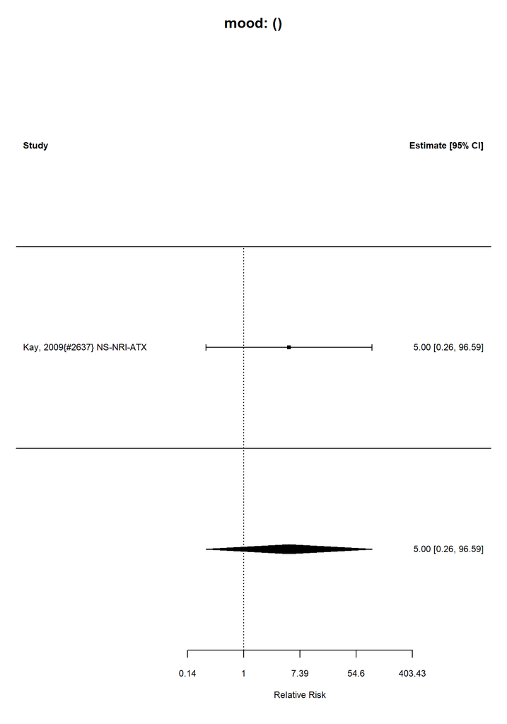

Number of studies = 1  
Intervention sample = 16  
Control sample = 16  
Total sample = 32

### Relative Risk Estimate

|  | estimate | se | zval | pval | ci.lb | ci.ub |
| --- | --- | --- | --- | --- | --- | --- |
| intrcpt | 5.002811 | 4.526731 | 2.915379 | 1.336428 | 0.2592403 | 96.54411 |

I-squared = 0 %

# Break down by interventions

```r
if (subgroup == "") {
  for (current_intervention in sort(unique(d$intervention))) {
    cat(glue::glue("<h1> Intervention: {current_intervention}</h1> "))
    cat("xxxxxxx")
    medication_analysis <- current_intervention == "Medication"
    # If current_intervention is medication, we're going to also use
    # comparator as an intervention group, as long as the intervention is not
    # also medication
    # if doing medication analysis, we also want medication in comparator
    if (!medication_analysis) {
      d_short <- d %>%
        dplyr::filter(
          intervention == current_intervention |
            comparator == current_intervention,
        )
    } else {
      d_short <- d %>%
        dplyr::filter(
          intervention == current_intervention |
            comparator == current_intervention,
        )
    }

    for (var_num in 1:length(list_variable_types)) {

      outcome_name <- list_variable_types[[var_num]]["var"]
      outcome_type <- list_variable_types[[var_num]]["type"]

      cat(
        glue::glue(
          "<h3>Outcome: {outcome_name}:{outcome_type}
          Intervention: {current_intervention}</h3><p>")
      )

      if (outcome_type == "continuous") {
        res <- ContMA(
          data = d_short,
          label = "ID",
          outcome = outcome_name,
          comparator_vs_int = comparator_vs_int
        )
      }
      if (outcome_type == "categorical") {
        print(glue::glue("Outcome name: {outcome_name}"))
#        if (outcome_name == "symptom" & current_intervention == "cognitive") {
#          stop("Got to cog cat")
#        }
        res <- CatMA(
          data = d_short,
          label = "ID",
          outcome = outcome_name,
          comparator_vs_int = comparator_vs_int,
          medication_analysis = medication_analysis
        )

      }
    }
  }
}
```

# Intervention: Medication

xxxxxxx

### Outcome: functional:continuous Intervention: Medication

| ID | measure | mean_ctrl_cont | SD_ctrl_cont | n_ctrl_cont | mean_int_cont | SD_int_cont | n_int_cont | yi | se | study.design |
| --- | --- | --- | --- | --- | --- | --- | --- | --- | --- | --- |
| Shim, 2022{#3242} NS-NRI-ATX | SDS (Sheehan Disability Scale) | 3.906 | 6.827 | 22 | 4.464 | 7.623 | 19 | -0.0759423 | 0.3132993 | RCT |

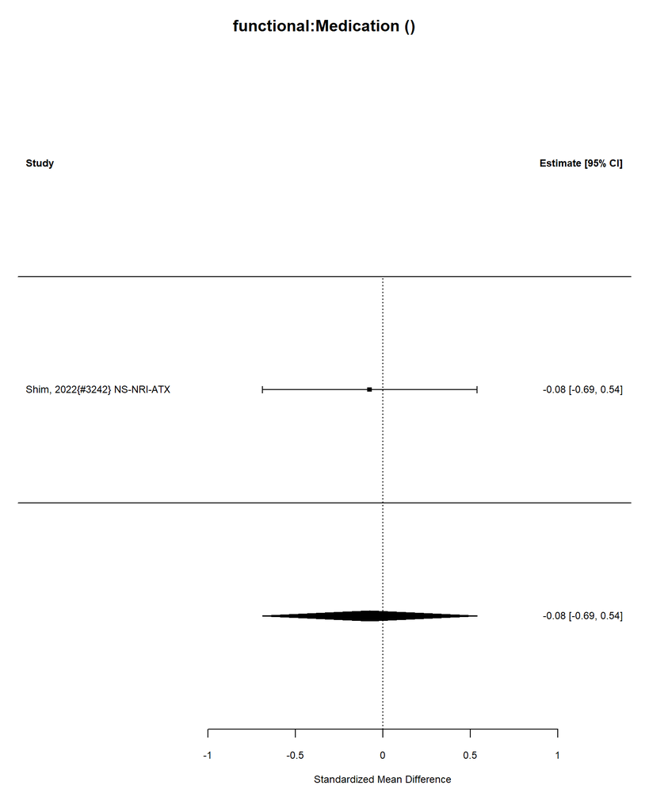

| estimate | conf.low | conf.high |
| --- | --- | --- |
| -0.08 | -0.69 | 0.54 |

Number of studies = 1

Intervention sample = 19

Control sample = 22

Total sample = 41.

I-squared = 0 %

Convert Effect Size to Real Units

Estimated effect in original units = -0.52.

### Outcome: functional:categorical Intervention: Medication

Outcome name: functional Analyzing 0 studies.

No data.

### Outcome: cognitive:continuous Intervention: Medication

No data #1.

### Outcome: cognitive:categorical Intervention: Medication

Outcome name: cognitive Analyzing 0 studies.

No data.

### Outcome: symptom:continuous Intervention: Medication

| ID | measure | mean_ctrl_cont | SD_ctrl_cont | n_ctrl_cont | mean_int_cont | SD_int_cont | n_int_cont | yi | se | study.design |
| --- | --- | --- | --- | --- | --- | --- | --- | --- | --- | --- |
| Kay, 2009{#2637} NS-NRI-ATX | ADHD-RS-IV (ADHD Rating Scale IV, Adult) | 18.400 | 7.200 | 15 | 27.800 | 6.900 | 14 | 1.2945790 | 0.4086449 | Crossover |
| Shim, 2022{#3242} NS-NRI-ATX | ASRS (Adult ADHD Self-Report Scale), change from baseline | 8.469 | 10.907 | 22 | 9.857 | 12.492 | 19 | -0.1166796 | 0.3134520 | RCT |
| Weisler, 2012{#1844} NS-NRI-ATX | ADHD-RS-IV (Attention-Deficit/Hyperactivity Disorder Rating Scale, Version IV) change from baseline | -15.700 | 13.390 | 68 | -15.300 | 14.520 | 73 | 0.0284439 | 0.1685449 | RCT |

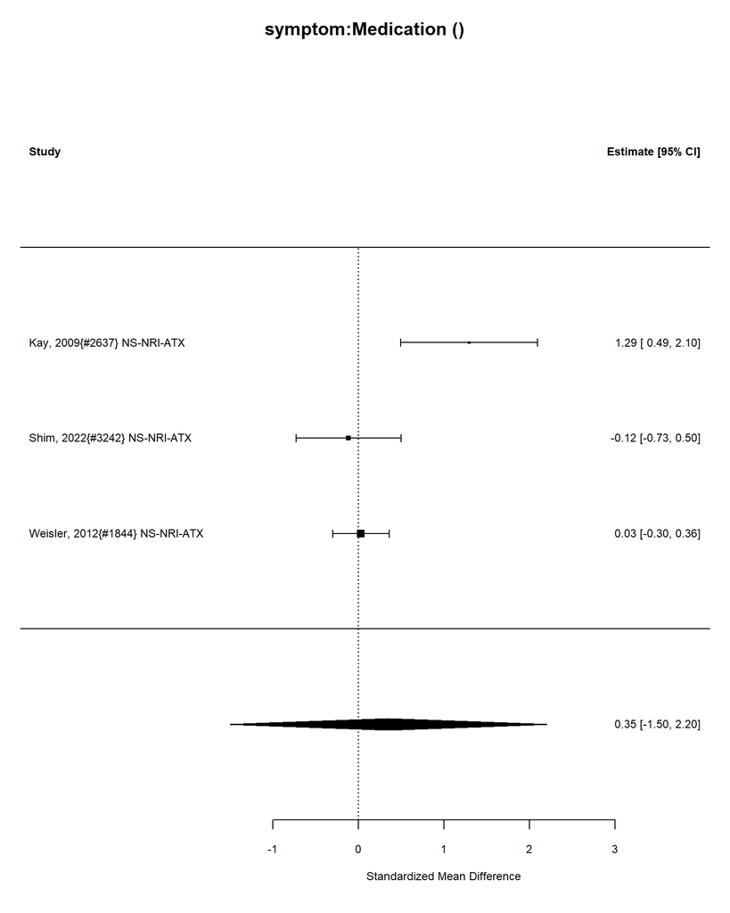

| estimate | conf.low | conf.high |
| --- | --- | --- |
| 0.35 | -1.5 | 2.2 |

Number of studies = 3

Intervention sample = 106

Control sample = 105

Total sample = 211.

I-squared = 84 %

Convert Effect Size to Real Units

Estimated effect in original units = 3.66.

##### Publication Bias Tests

###### Begg (non-parametric)

Rank Correlation Test for Funnel Plot Asymmetry Kendall’s tau = 1.0000, p = 0.3333

###### Egger (parametric)

Regression Test for Funnel Plot Asymmetry

Model: mixed-effects meta-regression model Predictor: standard error

Test for Funnel Plot Asymmetry: t = 1.0537, df = 1, p = 0.4834 Limit Estimate (as sei -> 0): b = -0.9240 (CI: -17.1864, 15.3384)

###### Trim and Fill

Estimate and Cis

|  | estimate | ci.lb | ci.ub |
| --- | --- | --- | --- |
| intrcpt | 0.35 | -1.5 | 2.2 |

### Meta-regression: stimulant vs non-stimulant

3 stimulant studies

0 nonstimulant studies

Not enough studies to compare stimulant and nonstimulant

### Meta-regression: AMPH vs MPH

### AMPH vs MPH meta-regression

1n AMPH studies

2 nMPH studies

Not enough studies to compare AMPH and MPH

## Meta-regression: Indirect comparison between combined vs(medication plus psychosocial) and medication

3 medication studies

0 combined studies

Not enough studies to compare medication and combined

## Meta-regression: Indirect comparison between combined vs(medication plus psychosocial) and psychosocial

0 psychosocial studies

0 combined studies

Not enough studies to compare psychosocial and combined

### Outcome: symptom:categorical Intervention: Medication

Outcome name: symptom Analyzing 1 studies.

Analyzing 1 studies.

### Control Types

| control | n |
| --- | --- |
| Placebo | 1 |

| ID | measure | yi | se | study.design |
| --- | --- | --- | --- | --- |
| Kay, 2009{#2637} NS-NRI-ATX | ADHD-RS score improvement from baseline (≥ 30% decrease from baseline) | 0.62 | 0.33 | Crossover |

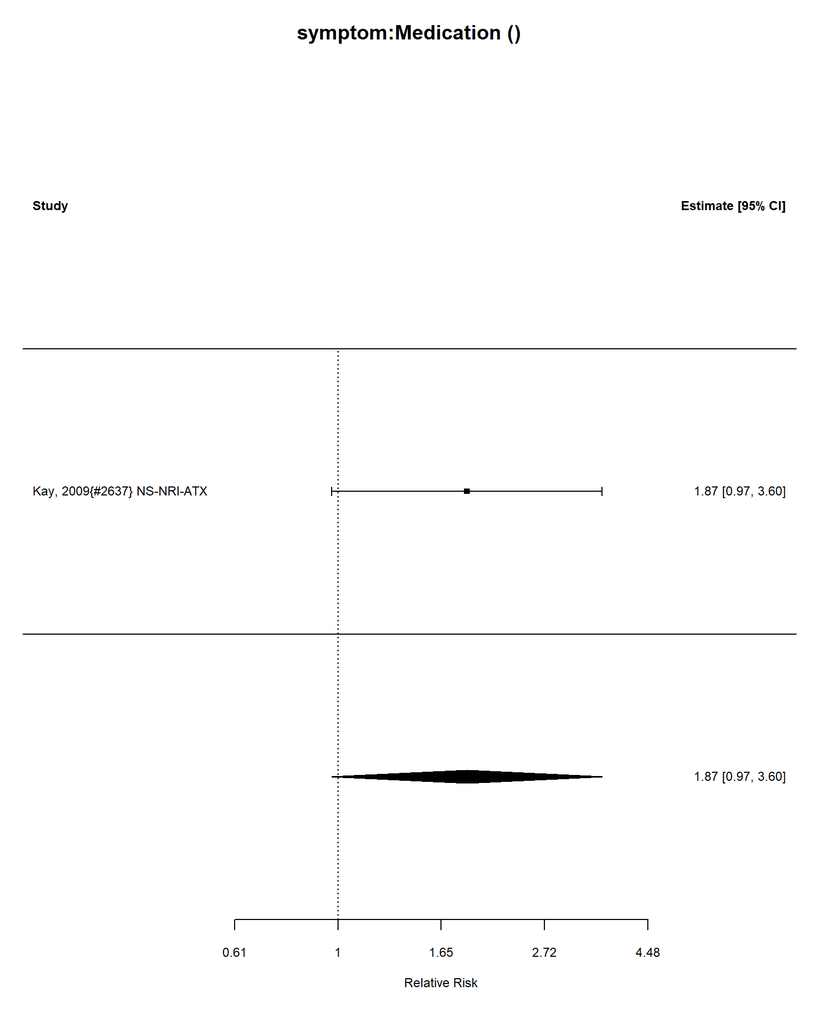

Number of studies = 1  
Intervention sample = 14  
Control sample = 14  
Total sample = 28

### Relative Risk Estimate

|  | estimate | se | zval | pval | ci.lb | ci.ub |
| --- | --- | --- | --- | --- | --- | --- |
| intrcpt | 1.858928 | 1.390968 | 6.488296 | 1.061837 | 0.9704455 | 3.59664 |

I-squared = 0 %

### Outcome: substance_use:continuous Intervention: Medication

No data #1.

### Outcome: substance_use:categorical Intervention: Medication

Outcome name: substance_use Analyzing 0 studies.

No data.

### Outcome: relationship:continuous Intervention: Medication

No data #1.

### Outcome: relationship:categorical Intervention: Medication

Outcome name: relationship Analyzing 0 studies.

No data.

### Outcome: BP:continuous Intervention: Medication

| ID | measure | mean_ctrl_cont | SD_ctrl_cont | n_ctrl_cont | mean_int_cont | SD_int_cont | n_int_cont | yi | se | study.design |
| --- | --- | --- | --- | --- | --- | --- | --- | --- | --- | --- |
| Kay, 2009{#2637} NS-NRI-ATX | Systolic blood pressure | 120.5 | 7.2 | 15 | 118.1 | 7.0 | 14 | -0.3283321 | 0.3741041 | Crossover |
| Shim, 2022{#3242} NS-NRI-ATX | Systolic blood pressure | 124.4 | 14.4 | 22 | 121.6 | 8.9 | 19 | -0.2255362 | 0.3141758 | RCT |

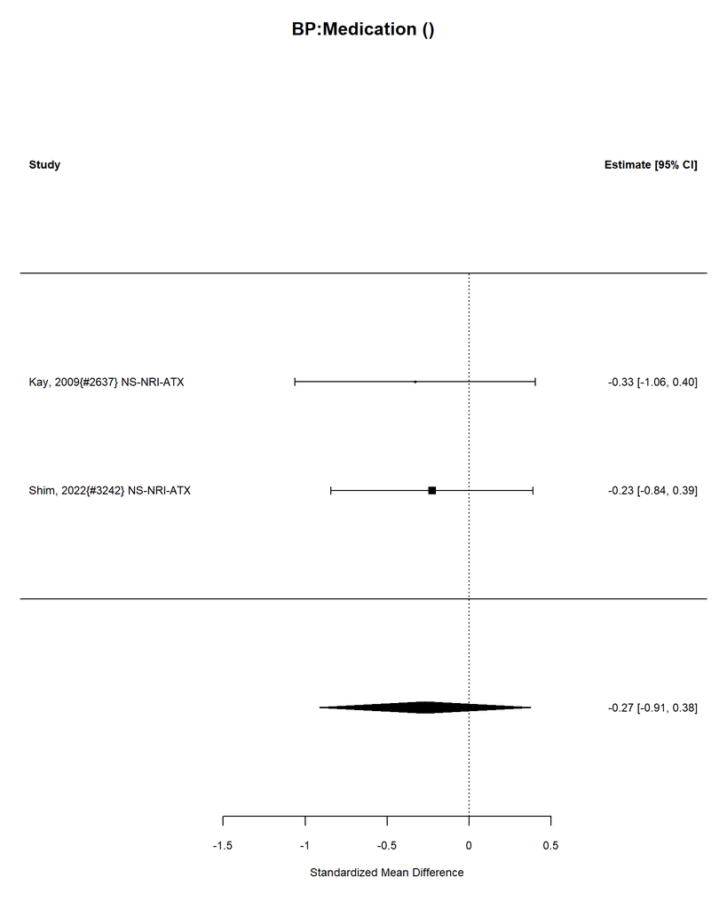

| estimate | conf.low | conf.high |
| --- | --- | --- |
| -0.27 | -0.91 | 0.38 |

Number of studies = 2

Intervention sample = 33

Control sample = 37

Total sample = 70.

I-squared = 0 %

Convert Effect Size to Real Units

Estimated effect in original units = -2.89.

### Outcome: BP:categorical Intervention: Medication

Outcome name: BP Analyzing 0 studies.

No data.

### Outcome: sleep_disturbance:continuous Intervention: Medication

No data #1.

### Outcome: sleep_disturbance:categorical Intervention: Medication

Outcome name: sleep_disturbance Analyzing 1 studies.

Analyzing 1 studies.

### Control Types

| control | n |
| --- | --- |
| Placebo | 1 |

| ID | measure | yi | se | study.design |
| --- | --- | --- | --- | --- |
| Weisler, 2012{#1844} NS-NRI-ATX | Number of participants reporting insomnia | -1.47 | 1.11 | RCT |

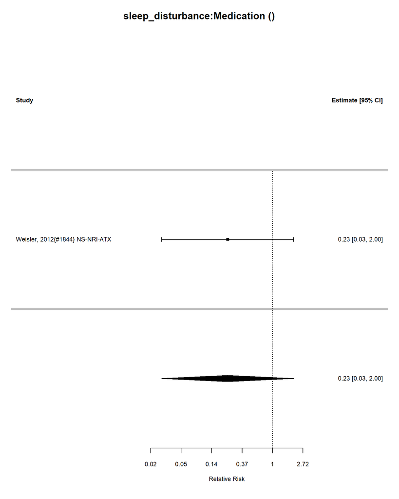

Number of studies = 1  
Intervention sample = 74  
Control sample = 73  
Total sample = 147

### Relative Risk Estimate

|  | estimate | se | zval | pval | ci.lb | ci.ub |
| --- | --- | --- | --- | --- | --- | --- |
| intrcpt | 0.2299255 | 3.034358 | 0.2644773 | 1.197217 | 0.0262523 | 2.013753 |

I-squared = 0 %

### Outcome: AEs:continuous Intervention: Medication

No data #1.

### Outcome: AEs:categorical Intervention: Medication

Outcome name: AEs Analyzing 1 studies.

Analyzing 1 studies.

### Control Types

| control | n |
| --- | --- |
| Placebo | 1 |

| ID | measure | yi | se | study.design |
| --- | --- | --- | --- | --- |
| Weisler, 2012{#1844} NS-NRI-ATX | Number of participants reporting any adverse events | 0.02 | 0.08 | RCT |

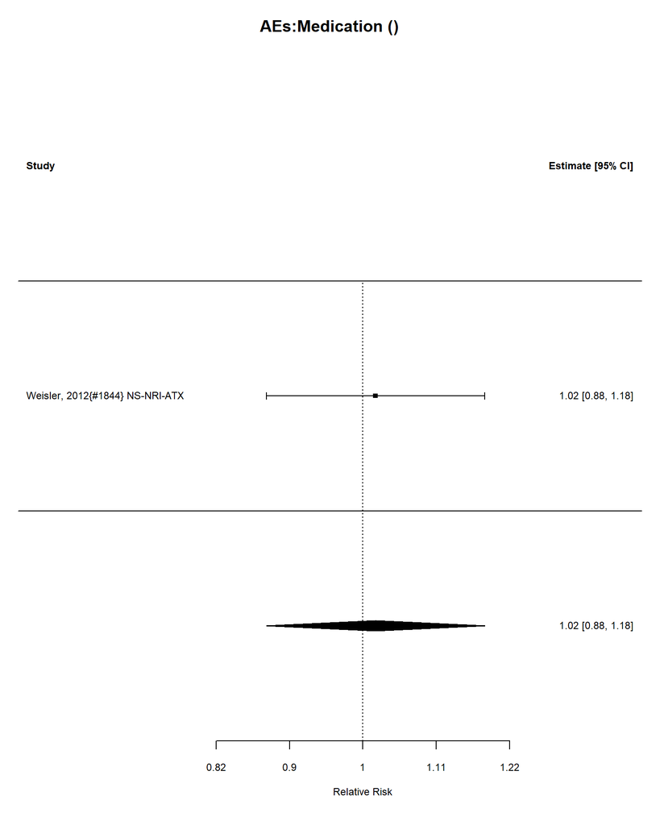

Number of studies = 1  
Intervention sample = 74  
Control sample = 73  
Total sample = 147

### Relative Risk Estimate

|  | estimate | se | zval | pval | ci.lb | ci.ub |
| --- | --- | --- | --- | --- | --- | --- |
| intrcpt | 1.020201 | 1.083287 | 1.2586 | 2.2705 | 0.8780954 | 1.185305 |

I-squared = 0 %

### Outcome: mortality:continuous Intervention: Medication

No data #1.

### Outcome: mortality:categorical Intervention: Medication

Outcome name: mortality Analyzing 1 studies.

Analyzing 1 studies.

### Control Types

| control | n |
| --- | --- |
| Placebo | 1 |

| ID | measure | yi | se | study.design |
| --- | --- | --- | --- | --- |
| Weisler, 2012{#1844} NS-NRI-ATX | Number of deaths | 0.08 | 1.99 | RCT |

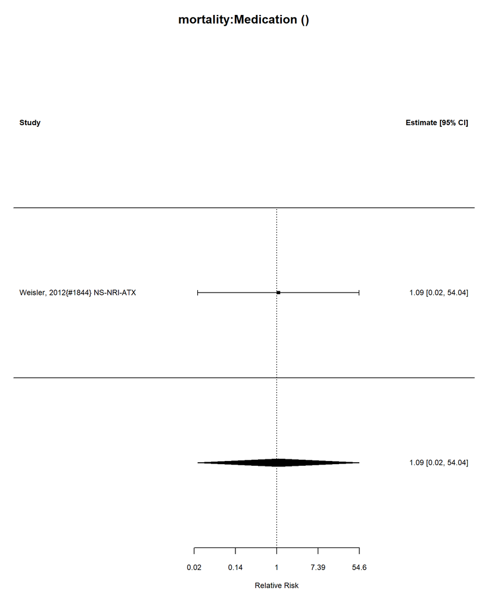

Number of studies = 1  
Intervention sample = 74  
Control sample = 73  
Total sample = 147

### Relative Risk Estimate

|  | estimate | se | zval | pval | ci.lb | ci.ub |
| --- | --- | --- | --- | --- | --- | --- |
| intrcpt | 1.083287 | 7.315534 | 1.040811 | 2.637945 | 0.0219278 | 54.05489 |

I-squared = 0 %

### Outcome: behavior:continuous Intervention: Medication

No data #1.

### Outcome: behavior:categorical Intervention: Medication

Outcome name: behavior Analyzing 0 studies.

No data.

### Outcome: appetite:continuous Intervention: Medication

No data #1.

### Outcome: appetite:categorical Intervention: Medication

Outcome name: appetite Analyzing 1 studies.

Analyzing 1 studies.

### Control Types

| control | n |
| --- | --- |
| Placebo | 1 |

| ID | measure | yi | se | study.design |
| --- | --- | --- | --- | --- |
| Weisler, 2012{#1844} NS-NRI-ATX | Decreased appetite adverse event | -0.8 | 0.42 | RCT |

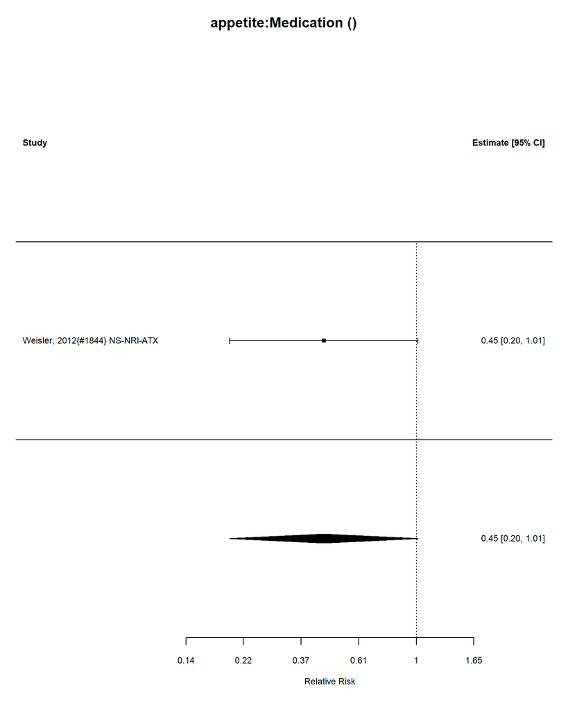

Number of studies = 1  
Intervention sample = 74  
Control sample = 73  
Total sample = 147

### Relative Risk Estimate

|  | estimate | se | zval | pval | ci.lb | ci.ub |
| --- | --- | --- | --- | --- | --- | --- |
| intrcpt | 0.449329 | 1.521962 | 0.1451482 | 1.051271 | 0.1978987 | 1.01005 |

I-squared = 0 %

### Outcome: mood:continuous Intervention: Medication

No data #1.

### Outcome: mood:categorical Intervention: Medication

Outcome name: mood Analyzing 1 studies.

Analyzing 1 studies.

### Control Types

| control | n |
| --- | --- |
| Placebo | 1 |

| ID | measure | yi | se | study.design |
| --- | --- | --- | --- | --- |
| Kay, 2009{#2637} NS-NRI-ATX | Irritability | 1.61 | 1.51 | Crossover |

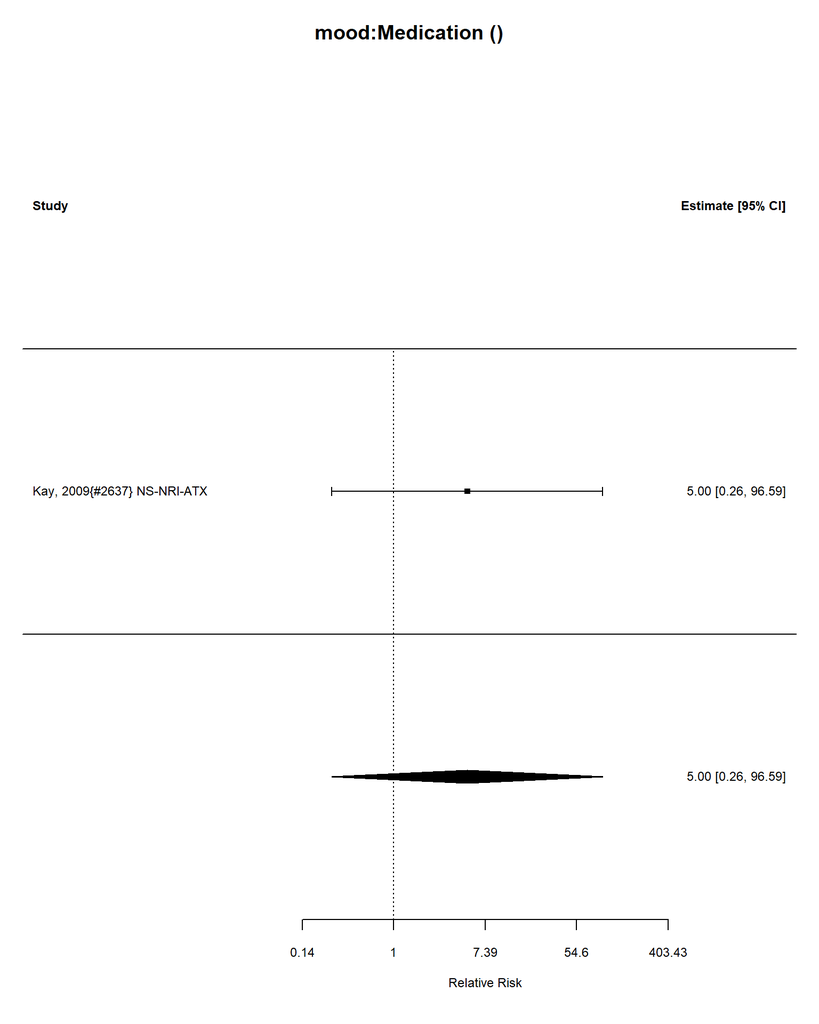

Number of studies = 1  
Intervention sample = 16  
Control sample = 16  
Total sample = 32

### Relative Risk Estimate

|  | estimate | se | zval | pval | ci.lb | ci.ub |
| --- | --- | --- | --- | --- | --- | --- |
| intrcpt | 5.002811 | 4.526731 | 2.915379 | 1.336428 | 0.2592403 | 96.54411 |

I-squared = 0 %

# Subintervention Analysis

Perform meta-analyses separately for MPH, AMPH, and NRI’s on ADHD symptoms, cognitive performance, and adverse events (p.28)? Reviewers and readers will absolutely expect and want it.

int_methylphenidate int_amphetamine int_NRI

• Perform meta-analyses separately for MBCT, DBT, and CBT on ADHD symptoms (p.33)? - int_mindfulness - int_DBT - int_CBT_only

Continuous Outcomes: - cognitive symptom AEs Categorical outcomes: - cognitive symptom AEs

```r
#Only doing specific interventions, and only specific outcomes.



sub_interventions <-
  c("longterm",
    "int_stimulant", "int_nonstimulant",
    "int_methylphenidate", "int_amphetamine",
    "int_NRI", "int_alpha_agonist", "int_atomoxetine",
    "int_bupropion",
    "int_mindfulness", "int_DBT_only", "int_CBT_only", "int_MBCT_only"
    )


rm(d_short)

for (current_intervention in sort(unique(sub_interventions))) {

  medication_analysis <- FALSE
  if (current_intervention %in%
      c("int_methylphenidate", "int_amphetamine", "int_NRI",
        "int_stimulant",
        "int_nonstimulant")) {
    medication_analysis <- TRUE
  }

  d_short <- d[d[current_intervention] == current_intervention, ]

  medication_analysis <- FALSE
  if (current_intervention %in%
      c("int_methylphenidate", "int_amphetamine", "int_NRI",
        "int_stimulant",
        "int_nonstimulant")) {
    medication_analysis <- TRUE
  }


  cat(glue::glue("<h2> MPH, AMPH, and NRI's Section:
                 Intervention: {current_intervention}</h2> "))
  for (var_num in 1:length(list_variable_types)) {

    outcome_name <- list_variable_types[[var_num]]["var"]
    outcome_type <- list_variable_types[[var_num]]["type"]

    cat(
      glue::glue("<h2> Intervention: {current_intervention} <br>
                <h3>Outcome: {outcome_name}:{outcome_type}</h3><p>")
    )

    if (outcome_type == "continuous") {
      res <- ContMA(
        data = d_short,
        label = "ID",
        outcome = outcome_name,
        comparator_vs_int = comparator_vs_int
      )
    }
    if (outcome_type == "categorical") {
      res <- CatMA(
        data = d_short,
        label = "ID",
        outcome = outcome_name,
        comparator_vs_int = comparator_vs_int
      )
    }
  }
}
```

## MPH, AMPH, and NRI’s Section: Intervention: int_alpha_agonist

## Intervention: int_alpha_agonist

### Outcome: functional:continuous

No data #1.

## Intervention: int_alpha_agonist

### Outcome: functional:categorical

Analyzing 0 studies.

No data.

## Intervention: int_alpha_agonist

### Outcome: cognitive:continuous

No data #1.

## Intervention: int_alpha_agonist

### Outcome: cognitive:categorical

Analyzing 0 studies.

No data.

## Intervention: int_alpha_agonist

### Outcome: symptom:continuous

No data #1.

## Intervention: int_alpha_agonist

### Outcome: symptom:categorical

Analyzing 0 studies.

No data.

## Intervention: int_alpha_agonist

### Outcome: substance_use:continuous

No data #1.

## Intervention: int_alpha_agonist

### Outcome: substance_use:categorical

Analyzing 0 studies.

No data.

## Intervention: int_alpha_agonist

### Outcome: relationship:continuous

No data #1.

## Intervention: int_alpha_agonist

### Outcome: relationship:categorical

Analyzing 0 studies.

No data.

## Intervention: int_alpha_agonist

### Outcome: BP:continuous

No data #1.

## Intervention: int_alpha_agonist

### Outcome: BP:categorical

Analyzing 0 studies.

No data.

## Intervention: int_alpha_agonist

### Outcome: sleep_disturbance:continuous

No data #1.

## Intervention: int_alpha_agonist

### Outcome: sleep_disturbance:categorical

Analyzing 0 studies.

No data.

## Intervention: int_alpha_agonist

### Outcome: AEs:continuous

No data #1.

## Intervention: int_alpha_agonist

### Outcome: AEs:categorical

Analyzing 0 studies.

No data.

## Intervention: int_alpha_agonist

### Outcome: mortality:continuous

No data #1.

## Intervention: int_alpha_agonist

### Outcome: mortality:categorical

Analyzing 0 studies.

No data.

## Intervention: int_alpha_agonist

### Outcome: behavior:continuous

No data #1.

## Intervention: int_alpha_agonist

### Outcome: behavior:categorical

Analyzing 0 studies.

No data.

## Intervention: int_alpha_agonist

### Outcome: appetite:continuous

No data #1.

## Intervention: int_alpha_agonist

### Outcome: appetite:categorical

Analyzing 0 studies.

No data.

## Intervention: int_alpha_agonist

### Outcome: mood:continuous

No data #1.

## Intervention: int_alpha_agonist

### Outcome: mood:categorical

Analyzing 0 studies.

No data.

## MPH, AMPH, and NRI’s Section: Intervention: int_amphetamine

## Intervention: int_amphetamine

### Outcome: functional:continuous

No data #1.

## Intervention: int_amphetamine

### Outcome: functional:categorical

Analyzing 0 studies.

No data.

## Intervention: int_amphetamine

### Outcome: cognitive:continuous

No data #1.

## Intervention: int_amphetamine

### Outcome: cognitive:categorical

Analyzing 0 studies.

No data.

## Intervention: int_amphetamine

### Outcome: symptom:continuous

No data #1.

## Intervention: int_amphetamine

### Outcome: symptom:categorical

Analyzing 0 studies.

No data.

## Intervention: int_amphetamine

### Outcome: substance_use:continuous

No data #1.

## Intervention: int_amphetamine

### Outcome: substance_use:categorical

Analyzing 0 studies.

No data.

## Intervention: int_amphetamine

### Outcome: relationship:continuous

No data #1.

## Intervention: int_amphetamine

### Outcome: relationship:categorical

Analyzing 0 studies.

No data.

## Intervention: int_amphetamine

### Outcome: BP:continuous

No data #1.

## Intervention: int_amphetamine

### Outcome: BP:categorical

Analyzing 0 studies.

No data.

## Intervention: int_amphetamine

### Outcome: sleep_disturbance:continuous

No data #1.

## Intervention: int_amphetamine

### Outcome: sleep_disturbance:categorical

Analyzing 0 studies.

No data.

## Intervention: int_amphetamine

### Outcome: AEs:continuous

No data #1.

## Intervention: int_amphetamine

### Outcome: AEs:categorical

Analyzing 0 studies.

No data.

## Intervention: int_amphetamine

### Outcome: mortality:continuous

No data #1.

## Intervention: int_amphetamine

### Outcome: mortality:categorical

Analyzing 0 studies.

No data.

## Intervention: int_amphetamine

### Outcome: behavior:continuous

No data #1.

## Intervention: int_amphetamine

### Outcome: behavior:categorical

Analyzing 0 studies.

No data.

## Intervention: int_amphetamine

### Outcome: appetite:continuous

No data #1.

## Intervention: int_amphetamine

### Outcome: appetite:categorical

Analyzing 0 studies.

No data.

## Intervention: int_amphetamine

### Outcome: mood:continuous

No data #1.

## Intervention: int_amphetamine

### Outcome: mood:categorical

Analyzing 0 studies.

No data.

## MPH, AMPH, and NRI’s Section: Intervention: int_atomoxetine

## Intervention: int_atomoxetine

### Outcome: functional:continuous

| ID | measure | mean_ctrl_cont | SD_ctrl_cont | n_ctrl_cont | mean_int_cont | SD_int_cont | n_int_cont | yi | se | study.design |
| --- | --- | --- | --- | --- | --- | --- | --- | --- | --- | --- |
| Shim, 2022{#3242} NS-NRI-ATX | SDS (Sheehan Disability Scale) | 3.906 | 6.827 | 22 | 4.464 | 7.623 | 19 | -0.0759423 | 0.3132993 | RCT |

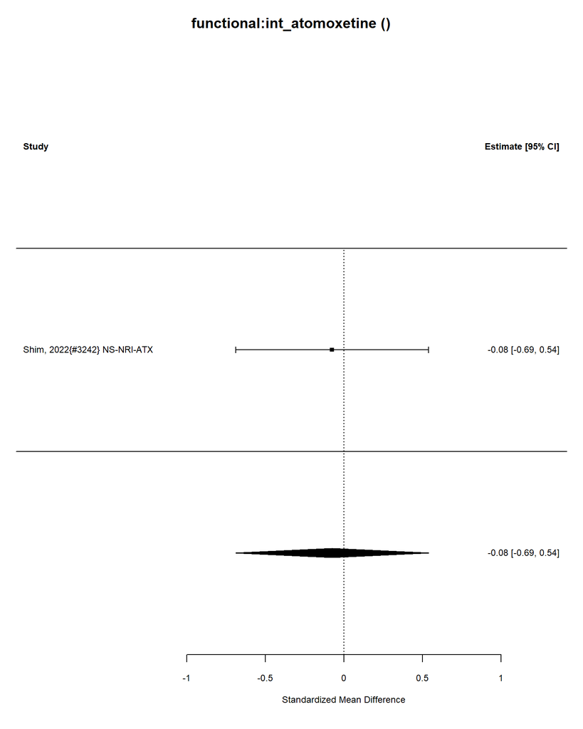

| estimate | conf.low | conf.high |
| --- | --- | --- |
| -0.08 | -0.69 | 0.54 |

Number of studies = 1

Intervention sample = 19

Control sample = 22

Total sample = 41.

I-squared = 0 %

Convert Effect Size to Real Units

Estimated effect in original units = -0.52.

## Intervention: int_atomoxetine

### Outcome: functional:categorical

Analyzing 0 studies.

No data.